# Projet ML- Construction de Véhiculier

2024-10-23

L’objectif de ce projet est de construire un véhiculier permettant de classer les véhicules du parc automobile en des groupes homogènes selon les fréquences de survenance de sinistres.

```r
library(dplyr)
library(lubridate)
library(h2o)
h2o.init()
```

```
##  Connection successful!
##
## R is connected to the H2O cluster:
##     H2O cluster uptime:         1 days 3 hours
##     H2O cluster timezone:       Europe/Paris
##     H2O data parsing timezone:  UTC
##     H2O cluster version:        3.44.0.3
##     H2O cluster version age:    10 months and 3 days
##     H2O cluster name:           H2O_started_from_R_wejde_sci958
##     H2O cluster total nodes:    1
##     H2O cluster total memory:   3.86 GB
##     H2O cluster total cores:    12
##     H2O cluster allowed cores:  12
##     H2O cluster healthy:        TRUE
##     H2O Connection ip:          localhost
##     H2O Connection port:        54321
##     H2O Connection proxy:       NA
##     H2O Internal Security:      FALSE
##     R Version:                  R version 4.4.1 (2024-06-14 ucrt)
```

```r
h2o.removeAll()
```

## Etape 0 : Compréhension des Données

#### Importation des Données

```r
df=read.csv("Motor vehicle insurance data.csv", sep=";")
```

```r
head(df,10)
```

```
##    ID Date_start_contract Date_last_renewal Date_next_renewal Date_birth
## 1   1          05/11/2015        05/11/2015        05/11/2016 15/04/1956
## 2   1          05/11/2015        05/11/2016        05/11/2017 15/04/1956
## 3   1          05/11/2015        05/11/2017        05/11/2018 15/04/1956
## 4   1          05/11/2015        05/11/2018        05/11/2019 15/04/1956
## 5   2          26/09/2017        26/09/2017        26/09/2018 15/04/1956
## 6   2          26/09/2017        26/09/2018        26/09/2019 15/04/1956
## 7   3          29/11/2013        29/11/2015        29/11/2016 18/03/1975
## 8   3          29/11/2013        29/11/2016        29/11/2017 18/03/1975
## 9   3          29/11/2013        29/11/2017        29/11/2018 18/03/1975
## 10  3          29/11/2013        29/11/2018        29/11/2019 18/03/1975
##    Date_driving_licence Distribution_channel Seniority Policies_in_force
## 1            20/03/1976                    0         4                 1
## 2            20/03/1976                    0         4                 1
## 3            20/03/1976                    0         4                 2
```

[output cut: 51 more lines]

```r
str(df)
```

```
## 'data.frame':    105555 obs. of  30 variables:
##  $ ID                  : int  1 1 1 1 2 2 3 3 3 3 ...
##  $ Date_start_contract : chr  "05/11/2015" "05/11/2015" "05/11/2015" "05/11/2015" ...
##  $ Date_last_renewal   : chr  "05/11/2015" "05/11/2016" "05/11/2017" "05/11/2018" ...
##  $ Date_next_renewal   : chr  "05/11/2016" "05/11/2017" "05/11/2018" "05/11/2019" ...
##  $ Date_birth          : chr  "15/04/1956" "15/04/1956" "15/04/1956" "15/04/1956" ...
##  $ Date_driving_licence: chr  "20/03/1976" "20/03/1976" "20/03/1976" "20/03/1976" ...
##  $ Distribution_channel: chr  "0" "0" "0" "0" ...
##  $ Seniority           : int  4 4 4 4 4 4 15 15 15 15 ...
##  $ Policies_in_force   : int  1 1 2 2 2 2 1 1 1 1 ...
##  $ Max_policies        : int  2 2 2 2 2 2 2 2 2 2 ...
##  $ Max_products        : int  1 1 1 1 1 1 1 1 1 1 ...
##  $ Lapse               : int  0 0 0 0 0 0 0 0 0 0 ...
##  $ Date_lapse          : chr  "" "" "" "" ...
##  $ Payment             : int  0 0 0 0 1 1 0 0 0 0 ...
```

[output cut: 16 more lines]

Notre base de données est constituée de 105555 observations et de 30 variables dont certaines sont relatives à la sinistralité (comme le nombre de sinistres survenus au cours de l’année, le cout de sinistres, l’historique de fréquence,..) et d’autres aux caractéristiques du véhicule (comme la puissance, la valeur du véhicule, la capacité de cylindre,..)

Chaque Véhicule est identifié par un contrat repéré par un “ID” et chaque ligne correspond à une situation du risque dans le portefeuille.

#### Analyse des Données

```r
summary(df)
```

```
##        ID        Date_start_contract Date_last_renewal  Date_next_renewal
##  Min.   :    1   Length:105555       Length:105555      Length:105555
##  1st Qu.:12925   Class :character    Class :character   Class :character
##  Median :26082   Mode  :character    Mode  :character   Mode  :character
##  Mean   :26271
##  3rd Qu.:39754
##  Max.   :53502
##
##   Date_birth        Date_driving_licence Distribution_channel   Seniority
##  Length:105555      Length:105555        Length:105555        Min.   : 1.000
##  Class :character   Class :character     Class :character     1st Qu.: 3.000
##  Mode  :character   Mode  :character     Mode  :character     Median : 4.000
##                                                               Mean   : 6.697
##                                                               3rd Qu.: 9.000
##                                                               Max.   :40.000
##
##  Policies_in_force  Max_policies     Max_products       Lapse
##  Min.   : 1.000    Min.   : 1.000   Min.   :1.000   Min.   :0.0000
##  1st Qu.: 1.000    1st Qu.: 1.000   1st Qu.:1.000   1st Qu.:0.0000
##  Median : 1.000    Median : 2.000   Median :1.000   Median :0.0000
##  Mean   : 1.456    Mean   : 1.837   Mean   :1.066   Mean   :0.2218
##  3rd Qu.: 2.000    3rd Qu.: 2.000   3rd Qu.:1.000   3rd Qu.:0.0000
##  Max.   :17.000    Max.   :17.000   Max.   :4.000   Max.   :7.0000
##
##   Date_lapse           Payment          Premium        Cost_claims_year
##  Length:105555      Min.   :0.0000   Min.   :  40.14   Min.   :     0.0
##  Class :character   1st Qu.:0.0000   1st Qu.: 241.61   1st Qu.:     0.0
##  Mode  :character   Median :0.0000   Median : 292.28   Median :     0.0
##                     Mean   :0.3192   Mean   : 315.89   Mean   :   153.6
##                     3rd Qu.:1.0000   3rd Qu.: 361.64   3rd Qu.:     0.0
##                     Max.   :1.0000   Max.   :2993.34   Max.   :260853.2
##
##  N_claims_year     N_claims_history R_Claims_history    Type_risk
##  Min.   : 0.0000   Min.   : 0.000   Min.   : 0.0000   Min.   :1.000
##  1st Qu.: 0.0000   1st Qu.: 0.000   1st Qu.: 0.0000   1st Qu.:3.000
##  Median : 0.0000   Median : 1.000   Median : 0.0800   Median :3.000
##  Mean   : 0.3947   Mean   : 2.752   Mean   : 0.4252   Mean   :2.722
##  3rd Qu.: 0.0000   3rd Qu.: 4.000   3rd Qu.: 0.5900   3rd Qu.:3.000
##  Max.   :25.0000   Max.   :52.000   Max.   :26.0700   Max.   :4.000
##
```

[output cut: 9 more lines]

```
##  Min.   :  49      Min.   :   270.5   Min.   :0.000   Length:105555
##  1st Qu.:1390      1st Qu.: 13127.2   1st Qu.:3.000   Class :character
##  Median :1598      Median : 17608.8   Median :5.000   Mode  :character
##  Mean   :1618      Mean   : 18413.7   Mean   :4.068
##  3rd Qu.:1910      3rd Qu.: 22595.0   3rd Qu.:5.000
##  Max.   :7480      Max.   :220675.8   Max.   :6.000
##
##      Length          Weight
##  Min.   :1.978   Min.   :  43
##  1st Qu.:3.999   1st Qu.:1043
##  Median :4.230   Median :1205
##  Mean   :4.252   Mean   :1191
##  3rd Qu.:4.443   3rd Qu.:1388
##  Max.   :8.218   Max.   :7300
##  NA's   :10329
```

Nous remarquons l’existence de données manquantes au niveau de quelques variables à savoir “Length”. Nous vérifions alors ce taux par variable :

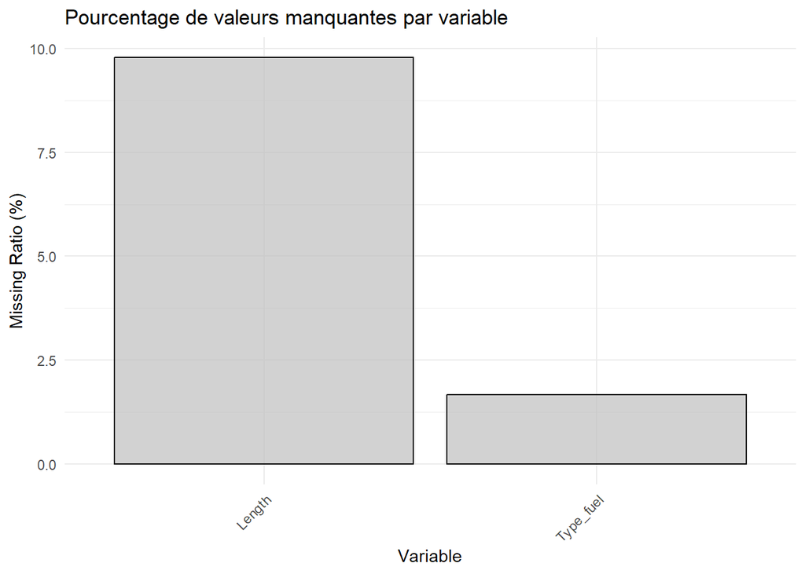

```r
library(ggplot2)
data_na <- (colSums(is.na(df)) / nrow(df)) * 100
data_na <- data_na[data_na > 0]
data_na <- data.frame(Variable=names(data_na), Missing_Ratio = data.frame(data_na)[,1])


# Plot bar chart
ggplot(data_na, aes(x = Variable, y = Missing_Ratio)) +
  geom_bar(stat = "identity", fill = "grey", color = "black", alpha = 0.7) +
  labs(title = "Pourcentage de valeurs manquantes par variable", x = "Variable", y = "Missing Ratio (%)") +
  theme_minimal() +
  theme(axis.text.x = element_text(angle = 45, hjust = 1))
```

Le taux de NA est faible, nous gardons alors toutes les variables.

Partant du fait que la classification des véhicules est basée sur la fréquence (nb de sinistres/exposition), et par soucis de simplicité, nous supposons que l’exposition est égale à une année donc elle prendra la valeur 1.

```r
df$EXPO=1
```

#### Zoom sur la Variable “N_claims_year”

```r
summary(df$N_claims_year)
```

```
##    Min. 1st Qu.  Median    Mean 3rd Qu.    Max.
##  0.0000  0.0000  0.0000  0.3947  0.0000 25.0000
```

A partir des statistiques descriptives de la variable N_claims_year, nous remarqueons que :

- Les différents quantiles sont de l’ordre de 0, sauf la moyenne et le quantile Q100 qui est égal à 25.

Dans une première étape, nous isolons l’effet véhicule (cad nous modélisons le nombre de sinistres en fonction des variables qui ne caractérisent pas le véhicule) L’effet de véhicule sera donc incorporé dans les résidus du modèle.

#### Prédiction de la fréquence de sinistres :

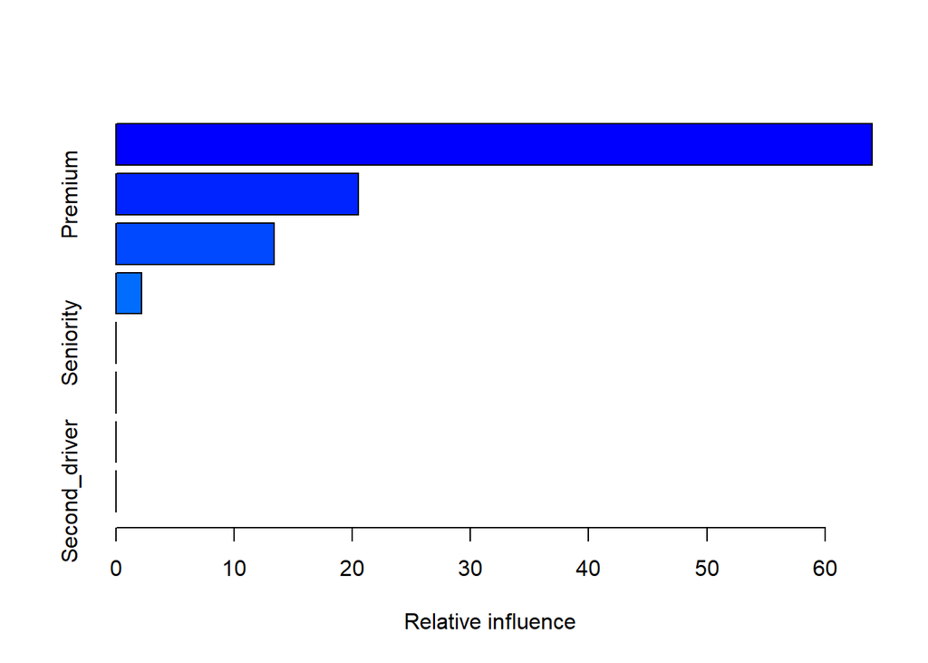

```
##                                 var   rel.inf
## Policies_in_force Policies_in_force 63.984289
## Premium                     Premium 20.491491
## Payment                     Payment 13.367782
## Type_risk                 Type_risk  2.156439
## Seniority                 Seniority  0.000000
## Area                           Area  0.000000
## Max_products           Max_products  0.000000
## Second_driver         Second_driver  0.000000
```

```r
library(gbm)
gbm_model <- gbm(N_claims_year ~ Premium + Seniority + Policies_in_force + Payment + Area + Type_risk + Max_products + Second_driver,
                 distribution = "poisson", data = df, n.trees = 100, interaction.depth = 4, shrinkage = 0.01, cv.folds = 5)

summary(gbm_model)
```

En fonction des variables sélectionnés, nous remarquons que celles les plus discriminantes sont “Policies in force” correspondant au nombre total de polices détenues par l’assuré auprès de l’entité d’assurance pendant la période, “Premium”, “Payment” représentant le mode de paiement et “Type_of_risk”.

Par la suite, nous estimons le nombre de sinistres et nous ajoutons cette prédiction comme une variable dans notre base.

```r
# Prédire les sinistres sur les données
gbm_predictions <- predict(gbm_model, newdata = df, n.trees = 100, type = "response")

# Ajouter les prédictions dans le dataframe
df$predicted_claims <- gbm_predictions

# Afficher un résumé des prédictions
summary(df$predicted_claims)
```

```
##    Min. 1st Qu.  Median    Mean 3rd Qu.    Max.
##  0.3061  0.3160  0.3387  0.3829  0.4080  1.4843
```

Nous évaluons ce modèle à l’aide de certains indicateurs comme la mesure de déviance et le RMSE.

```r
# Calcul de la déviance
deviance <- sum((df$N_claims_year - df$predicted_claims)^2) / nrow(df)
print(paste("Deviance:", round(deviance, 4)))
```

```
## [1] "Deviance: 1.1776"
```

```r
# Calcul du RMSE
rmse <- sqrt(mse <- mean((df$N_claims_year - df$predicted_claims)^2))
print(paste("RMSE:", round(rmse, 4)))
```

```
## [1] "RMSE: 1.0852"
```

Par la suite, nous ajoutons une variable correspondant à l’écart entre le nombre de sinistre observé et celui estimé hors effet véhicule.

```r
df$Res_diff=df$N_claims_year - df$predicted_claims
summary(df$Res_diff)
```

```
##     Min.  1st Qu.   Median     Mean  3rd Qu.     Max.
## -1.34226 -0.39517 -0.33645  0.01177 -0.30608 24.29500
```

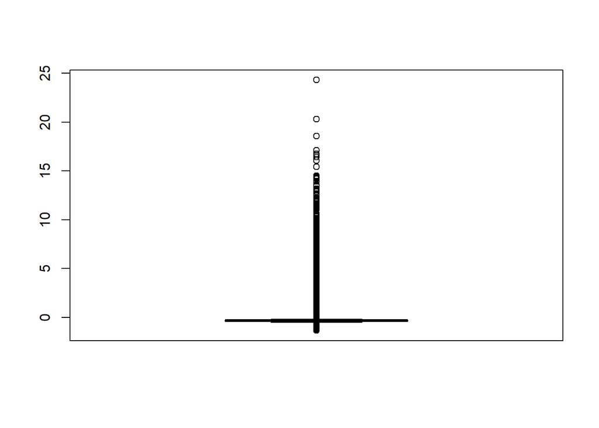

```r
boxplot(df$Res_diff)
```

Ces statistiques donnent un aperçu de la distribution de la variable Res_diff. La moyenne est différente de la médiane, cela suggère la présence de valeurs extrêmes dans la distribution. De plus, le 3ème quantile est inférieur à la moyenne : la distribution est étirée vers la droite (skewness à droite) par les valeurs extrêmes élevées (la valeur maximale du nombre de sinistres résiduel est très élevée par rapport aux autres valeurs).

Le diagramme à moustaches illustre bien la présence d’outliers. De telles observations peuvent biaiser les résultats, il est donc primordial de les supprimer ou éventuellement de réduire leur taux.

Remarque : dans la partie modélisation, nous comptons tester les modèles avant et après suppression de ces valeurs.

#### Détection et Suppression des Outliers

##### ) a- Méthode 1 : IQR criterion

Selon cette approche, toutes les observations en dehors de l’intervalle I=[Q1-1.5*IQR ; Q3+1.5*IQR] sont considérées comme des outliers.

```r
out <- boxplot.stats(df$Res_diff)$out
length(out)*100/nrow(df)
```

```
## [1] 24.38918
```

D’après cette méthode, nous avons environ 24% des observations sont considérées comme outliers. Ce taux est élevé, nous testerons alors une autre approche.

##### ) b- Méthode 2 : Percentiles

Cette approche s’appuie sur les percentiles pour identifier les valeurs aberrantes : les observations à l’extérieur de l’intevalle formé par les percentiles 2.5 et 97.5 sont considérées comme des outliers potentiels.

```r
lower_bound1 <- quantile(df$Res_diff, 0.025, na.rm = TRUE)
upper_bound1 <- quantile(df$Res_diff, 0.975, na.rm=TRUE)
outlier_ind1 <- which(df$Res_diff < lower_bound1 | df$Res_diff > upper_bound1)
length(outlier_ind1)*100/nrow(df)
```

```
## [1] 4.976553
```

```r
summary(df[df$Res_diff >= lower_bound1 & df$Res_diff <= upper_bound1,]$Res_diff)
```

```
##    Min. 1st Qu.  Median    Mean 3rd Qu.    Max.
## -0.5692 -0.3915 -0.3364 -0.1013 -0.3061  3.2817
```

5% des valeurs sont considérées comme aberrantes, et le nombre de sinistres résiduel varie entre -0.5 et 3.3. Nous testerons d’autres percentiles pour sélectionner les seuils le plus adéquants en faisant un compromis entre valeurs de seuils (bornes inf et sup de l’intervalle des observations non aberrantes) et taux de valeurs aberrantes (car nous ne pouvons pas supprimer un très grand nombre d’observations).

Soient alors les percentiles 1 et 99 :

```r
lower_bound2 <- quantile(df$Res_diff, 0.01, na.rm = TRUE)
upper_bound2 <- quantile(df$Res_diff, 0.99, na.rm = TRUE)
outlier_ind2 <- which(df$Res_diff < lower_bound2 | df$Res_diff > upper_bound2)
length(outlier_ind2)*100/nrow(df) #taux
```

```
## [1] 1.998958
```

```r
summary(df[df$Res_diff >= lower_bound2 & df$Res_diff <= upper_bound2,]$Res_diff)
```

```
##     Min.  1st Qu.   Median     Mean  3rd Qu.     Max.
## -0.69907 -0.39360 -0.33645 -0.04923 -0.30608  4.65834
```

Ce taux d’environ 2% semble meilleur, mais l’intervalle des valeurs non aberrantes sera [-0,69 , 4.65].

Nous testons, par la suite une autre approche issue de la TVE. Il s’agit de l’estimateur de Hill dont le seuil correspond au moment à partir duquel, cet estimateur ce stabilise.

##### ) c- Méthode 3 : HillPlot

```r
#install.packages("evmix")
library(evmix)
```

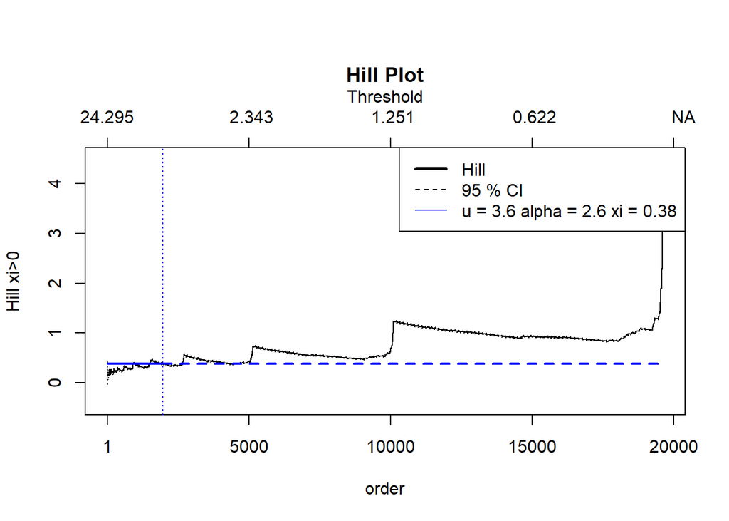

```r
hillplot(df$Res_diff)
```

```r
# Filtrer les lignes où Res_diff est entre les bornes
df_filtered <- df[df$Res_diff >= lower_bound1 & df$Res_diff <= upper_bound1, ]
```

## Etape 1 : Modélisation par GBM

### Avant Suppression des valuers aberrantes

#### Modèle : Variable à expliquer = Res_diff & Offset = EXPO

Nous éliminons les variables de type date et celles fortement corrélées avec le nombre de sinistre comme l’historique de fréquence et nous subdivisons la base en partie train et partie test.

```r
DF=df[,c(1,8:9,14:16, 20:31,33)]
```

#### Split train/test

```r
df=as.h2o(DF)
```

```
##   |                                                                              |                                                                      |   0%  |                                                                              |=========================================================…
```

```r
splits <- h2o.splitFrame(df, 0.8, seed=1234)
train <- h2o.assign(splits[[1]], "train.hex")
valid <- h2o.assign(splits[[2]], "valid.hex")
```

Par la suite, nous implémentons un modèle de prédiction du nombre de sinistres résiduel via un GBM en mettant l’exposition en offset.

```r
MOD_1 <- h2o.gbm(x=c(2:17),y = 19, offset_column="EXPO", training_frame = train, validation_frame = valid,ntrees = 50)
```

```
##   |                                                                              |                                                                      |   0%  |                                                                              |=================================================        …
```

```r
summary(MOD_1)
```

```
## Model Details:
## ==============
##
## H2ORegressionModel: gbm
## Model Key:  GBM_model_R_1729615305918_11
## Model Summary:
##   number_of_trees number_of_internal_trees model_size_in_bytes min_depth
## 1              50                       50               20031         5
##   max_depth mean_depth min_leaves max_leaves mean_leaves
## 1         5    5.00000         12         32    27.16000
##
## H2ORegressionMetrics: gbm
## ** Reported on training data. **
##
## MSE:  0.3944973
## RMSE:  0.6280902
## MAE:  0.1878001
## RMSLE:  NaN
## Mean Residual Deviance :  0.3944973
##
##
## H2ORegressionMetrics: gbm
## ** Reported on validation data. **
## ** Validation metrics **
##
## MSE:  0.4277969
## RMSE:  0.6540619
## MAE:  0.1930851
## RMSLE:  NaN
## Mean Residual Deviance :  0.4277969
##
##
##
##
## Scoring History:
##             timestamp   duration number_of_trees training_rmse training_mae
## 1 2024-10-23 22:34:09  0.047 sec               0       1.08602      0.62975
## 2 2024-10-23 22:34:09  0.095 sec               1       1.02034      0.56717
## 3 2024-10-23 22:34:09  0.126 sec               2       0.96280      0.51156
## 4 2024-10-23 22:34:09  0.173 sec               3       0.91387      0.46282
```

[output cut: 29 more lines]

```
## 1    Cost_claims_year       304350.281250          1.000000   0.873659
## 2   Policies_in_force        19131.292969          0.062859   0.054918
## 3           Seniority         6020.221191          0.019781   0.017281
## 4              Length         3201.021484          0.010518   0.009189
## 5   Cylinder_capacity         3090.143555          0.010153   0.008870
## 6             Premium         2639.962402          0.008674   0.007578
## 7  Year_matriculation         1881.774170          0.006183   0.005402
## 8              Weight         1831.845459          0.006019   0.005258
## 9             N_doors         1390.583862          0.004569   0.003992
## 10              Power         1237.094604          0.004065   0.003551
## 11      Value_vehicle         1235.302246          0.004059   0.003546
## 12            Payment         1186.445068          0.003898   0.003406
## 13          Type_risk          628.783264          0.002066   0.001805
## 14               Area          528.760559          0.001737   0.001518
## 15      Second_driver            9.236691          0.000030   0.000027
```

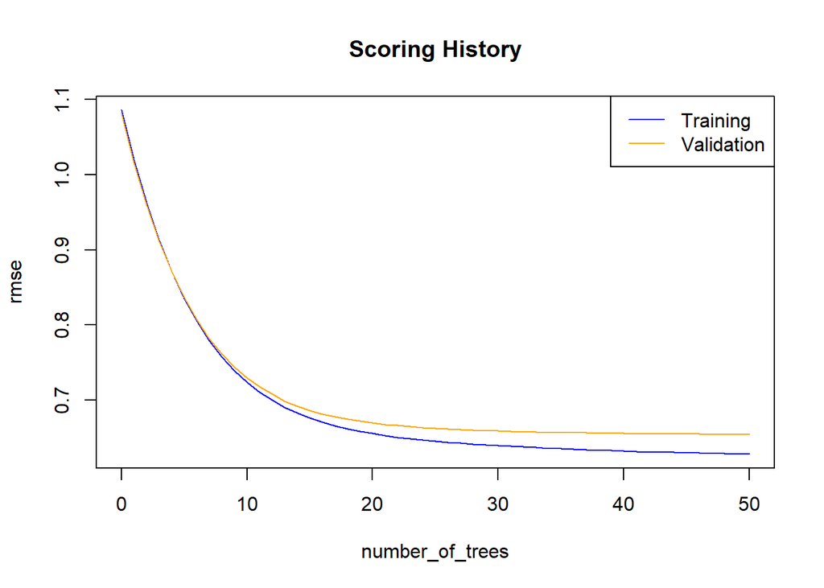

```r
plot(MOD_1,timestep="number_of_trees",metric="RMSE")
```

```r
output1=MOD_1@model$scoring_history
output1
```

```
## Scoring History:
##             timestamp   duration number_of_trees training_rmse training_mae
## 1 2024-10-23 22:34:09  0.047 sec               0       1.08602      0.62975
## 2 2024-10-23 22:34:09  0.095 sec               1       1.02034      0.56717
## 3 2024-10-23 22:34:09  0.126 sec               2       0.96280      0.51156
## 4 2024-10-23 22:34:09  0.173 sec               3       0.91387      0.46282
## 5 2024-10-23 22:34:09  0.205 sec               4       0.87147      0.42174
##   training_deviance validation_rmse validation_mae validation_deviance
## 1           1.17944         1.08140        0.62991             1.16942
## 2           1.04109         1.01599        0.56732             1.03224
## 3           0.92698         0.95934        0.51165             0.92034
## 4           0.83516         0.91206        0.46290             0.83185
## 5           0.75947         0.87108        0.42207             0.75878
##
## ---
##              timestamp   duration number_of_trees training_rmse training_mae
## 46 2024-10-23 22:34:11  1.592 sec              45       0.63004      0.18804
## 47 2024-10-23 22:34:11  1.624 sec              46       0.62957      0.18789
## 48 2024-10-23 22:34:11  1.657 sec              47       0.62899      0.18787
## 49 2024-10-23 22:34:11  1.689 sec              48       0.62872      0.18793
## 50 2024-10-23 22:34:11  1.705 sec              49       0.62852      0.18787
## 51 2024-10-23 22:34:11  1.752 sec              50       0.62809      0.18780
##    training_deviance validation_rmse validation_mae validation_deviance
## 46           0.39695         0.65504        0.19302             0.42908
## 47           0.39636         0.65475        0.19298             0.42870
## 48           0.39563         0.65468        0.19306             0.42861
## 49           0.39529         0.65436        0.19313             0.42818
## 50           0.39503         0.65422        0.19311             0.42801
## 51           0.39450         0.65406        0.19309             0.42780
```

Nous remarquons que les performances sont médiocres à la fois sur les données d’entrainement et de test : les erreurs trains et test sont élevées. Nous avons donc un problème d’underfitting : le modèle ne peut pas capturer la structure sous-jacente des données, ce qui conduit à une mauvaise capacité de généralisation.

### Après Suppression des valuers extremes

#### Modèle 2 : Variable à expliquer = Res_diff & Offset = EXPO

Nous supprimons les observations considérées comme aberrantes en respectant le seuil choisi dans la partie précédante et nous testons de nouveau le modèle.

```r
DF=df_filtered[,c(1,8:9,14:16, 20:31,33)]
```

#### Split train/test

```r
h2o.removeAll()

df=as.h2o(DF)
```

```
##   |                                                                              |                                                                      |   0%  |                                                                              |=========================================================…
```

```r
splits <- h2o.splitFrame(df, 0.8, seed=1234)
train <- h2o.assign(splits[[1]], "train.hex")
valid <- h2o.assign(splits[[2]], "valid.hex")
```

```r
MOD_2 <- h2o.gbm(x=c(2:17),y = 19, offset_column="EXPO", training_frame = train, validation_frame = valid,ntrees = 50)
```

```
##   |                                                                              |                                                                      |   0%  |                                                                              |=======================================================  …
```

```r
summary(MOD_2)
```

```
## Model Details:
## ==============
##
## H2ORegressionModel: gbm
## Model Key:  GBM_model_R_1729615305918_12
## Model Summary:
##   number_of_trees number_of_internal_trees model_size_in_bytes min_depth
## 1              50                       50               20947         5
##   max_depth mean_depth min_leaves max_leaves mean_leaves
## 1         5    5.00000         15         32    28.64000
##
## H2ORegressionMetrics: gbm
## ** Reported on training data. **
##
## MSE:  0.07477118
## RMSE:  0.2734432
## MAE:  0.09555663
## RMSLE:  0.1191374
## Mean Residual Deviance :  0.07477118
##
##
## H2ORegressionMetrics: gbm
## ** Reported on validation data. **
## ** Validation metrics **
##
## MSE:  0.08358168
## RMSE:  0.289105
## MAE:  0.101304
## RMSLE:  0.1245097
## Mean Residual Deviance :  0.08358168
##
##
##
##
## Scoring History:
##             timestamp   duration number_of_trees training_rmse training_mae
## 1 2024-10-23 22:34:21  0.054 sec               0       0.65484      0.43410
## 2 2024-10-23 22:34:21  0.100 sec               1       0.60214      0.39077
## 3 2024-10-23 22:34:21  0.131 sec               2       0.55579      0.35184
## 4 2024-10-23 22:34:21  0.163 sec               3       0.51519      0.31690
```

[output cut: 29 more lines]

```
## 1    Cost_claims_year       145659.328125          1.000000   0.974750
## 2   Policies_in_force          928.616699          0.006375   0.006214
## 3             Payment          590.327820          0.004053   0.003950
## 4           Seniority          555.582153          0.003814   0.003718
## 5             Premium          404.183411          0.002775   0.002705
## 6  Year_matriculation          246.055283          0.001689   0.001647
## 7       Value_vehicle          223.508072          0.001534   0.001496
## 8               Power          189.924149          0.001304   0.001271
## 9              Weight          186.703644          0.001282   0.001249
## 10  Cylinder_capacity          179.566818          0.001233   0.001202
## 11             Length          170.609238          0.001171   0.001142
## 12               Area           51.603382          0.000354   0.000345
## 13            N_doors           23.903973          0.000164   0.000160
## 14          Type_risk           11.926505          0.000082   0.000080
## 15      Second_driver           10.643271          0.000073   0.000071
```

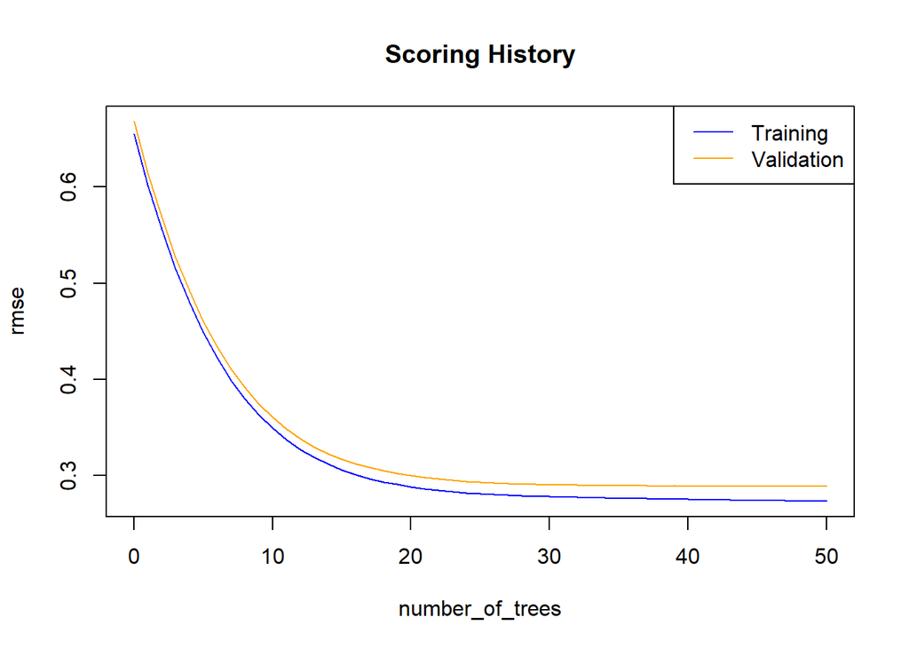

```r
plot(MOD_2,timestep="number_of_trees",metric="RMSE")
```

```r
output1=MOD_2@model$scoring_history
output1
```

```
## Scoring History:
##             timestamp   duration number_of_trees training_rmse training_mae
## 1 2024-10-23 22:34:21  0.054 sec               0       0.65484      0.43410
## 2 2024-10-23 22:34:21  0.100 sec               1       0.60214      0.39077
## 3 2024-10-23 22:34:21  0.131 sec               2       0.55579      0.35184
## 4 2024-10-23 22:34:21  0.163 sec               3       0.51519      0.31690
## 5 2024-10-23 22:34:21  0.194 sec               4       0.47975      0.28563
##   training_deviance validation_rmse validation_mae validation_deviance
## 1           0.42881         0.66803        0.44064             0.44627
## 2           0.36257         0.61498        0.39694             0.37820
## 3           0.30890         0.56832        0.35765             0.32299
## 4           0.26542         0.52741        0.32237             0.27816
## 5           0.23016         0.49169        0.29082             0.24176
##
## ---
##              timestamp   duration number_of_trees training_rmse training_mae
## 46 2024-10-23 22:34:22  1.473 sec              45       0.27433      0.09629
## 47 2024-10-23 22:34:22  1.504 sec              46       0.27414      0.09610
## 48 2024-10-23 22:34:22  1.520 sec              47       0.27396      0.09595
## 49 2024-10-23 22:34:22  1.565 sec              48       0.27380      0.09579
## 50 2024-10-23 22:34:22  1.583 sec              49       0.27364      0.09569
## 51 2024-10-23 22:34:22  1.624 sec              50       0.27344      0.09556
##    training_deviance validation_rmse validation_mae validation_deviance
## 46           0.07526         0.28919        0.10177             0.08363
## 47           0.07515         0.28917        0.10164             0.08362
## 48           0.07506         0.28916        0.10154             0.08361
## 49           0.07497         0.28913        0.10143             0.08359
## 50           0.07488         0.28904        0.10135             0.08355
## 51           0.07477         0.28910        0.10130             0.08358
```

Pour le 2eme modèle, la suppression d’outliers a un impact sur les erreurs (nous détectons une diminution par rapport aux résultats trouvés avant suppression). Le nombre d’arbres pour le tuning est fixé à 20.

#### Tuning du modèle 2

```r
gbm_parameters <- list(learn_rate = c(0.01,0.05, 0.1),
                        max_depth = c(3, 5, 6,7),
                        sample_rate = c(0.7, 0.75, 0.8),
                        col_sample_rate = c(0.2, 0.5, 1.0))
```

```r
gbm2_grid <- h2o.grid("gbm", x=c(2:17),y = 19,
                      grid_id = "gbm_grid",
                      training_frame = train,
                      validation_frame = valid,
                      ntrees=20,
                      hyper_params = gbm_parameters)
```

```
##   |                                                                              |                                                                      |   0%  |                                                                              |=========================================================…
```

```r
gbm2_gridp<- h2o.getGrid(grid_id = "gbm_grid",
                         sort_by = "rmse",
                         decreasing  = FALSE)
print(gbm2_gridp)
```

```
## H2O Grid Details
## ================
##
## Grid ID: gbm_grid
## Used hyper parameters:
##   -  col_sample_rate
##   -  learn_rate
##   -  max_depth
##   -  sample_rate
## Number of models: 108
## Number of failed models: 0
##
## Hyper-Parameter Search Summary: ordered by increasing rmse
##   col_sample_rate learn_rate max_depth sample_rate          model_ids    rmse
## 1         1.00000    0.10000   7.00000     0.80000 gbm_grid_model_108 0.29968
## 2         1.00000    0.10000   5.00000     0.80000  gbm_grid_model_90 0.29975
## 3         1.00000    0.10000   5.00000     0.75000  gbm_grid_model_54 0.29978
## 4         1.00000    0.10000   7.00000     0.75000  gbm_grid_model_72 0.30003
## 5         1.00000    0.10000   6.00000     0.70000  gbm_grid_model_27 0.30012
##
## ---
##     col_sample_rate learn_rate max_depth sample_rate         model_ids    rmse
## 103         0.20000    0.01000   5.00000     0.70000 gbm_grid_model_10 0.63005
## 104         0.20000    0.01000   5.00000     0.75000 gbm_grid_model_46 0.63367
## 105         0.20000    0.01000   3.00000     0.80000 gbm_grid_model_73 0.63702
## 106         0.20000    0.01000   3.00000     0.70000  gbm_grid_model_1 0.63942
## 107         0.20000    0.01000   3.00000     0.75000 gbm_grid_model_37 0.64098
## 108         0.20000    0.01000   5.00000     0.80000 gbm_grid_model_82 0.64973
```

#### Modele final

Nous retenons le meilleur modèle d’après la grille :

```r
best_MOD=h2o.getModel(gbm2_gridp@model_ids[[1]])

summary(best_MOD)
```

```
## Model Details:
## ==============
##
## H2ORegressionModel: gbm
## Model Key:  gbm_grid_model_108
## Model Summary:
##   number_of_trees number_of_internal_trees model_size_in_bytes min_depth
## 1              20                       20               25573         7
##   max_depth mean_depth min_leaves max_leaves mean_leaves
## 1         7    7.00000         76        108    97.05000
##
## H2ORegressionMetrics: gbm
## ** Reported on training data. **
##
## MSE:  0.07862992
## RMSE:  0.2804103
## MAE:  0.1155707
## RMSLE:  0.1270493
## Mean Residual Deviance :  0.07862992
##
##
## H2ORegressionMetrics: gbm
## ** Reported on validation data. **
## ** Validation metrics **
##
## MSE:  0.08981098
## RMSE:  0.2996848
## MAE:  0.1224646
## RMSLE:  0.134163
## Mean Residual Deviance :  0.08981098
##
##
##
##
## Scoring History:
##             timestamp          duration number_of_trees training_rmse
## 1 2024-10-23 22:35:27  1 min  2.527 sec               0       0.65484
## 2 2024-10-23 22:35:27  1 min  2.561 sec               1       0.60177
## 3 2024-10-23 22:35:27  1 min  2.598 sec               2       0.55496
## 4 2024-10-23 22:35:27  1 min  2.628 sec               3       0.51393
```

[output cut: 42 more lines]

```
## 1    Cost_claims_year       130423.250000          1.000000   0.970225
## 2   Policies_in_force          879.363281          0.006742   0.006542
## 3           Seniority          554.585815          0.004252   0.004126
## 4             Payment          517.580200          0.003968   0.003850
## 5             Premium          440.613739          0.003378   0.003278
## 6  Year_matriculation          310.534668          0.002381   0.002310
## 7       Value_vehicle          253.030975          0.001940   0.001882
## 8              Length          242.272186          0.001858   0.001802
## 9               Power          228.725708          0.001754   0.001702
## 10  Cylinder_capacity          215.568192          0.001653   0.001604
## 11             Weight          198.878922          0.001525   0.001479
## 12               Area           64.819374          0.000497   0.000482
## 13            N_doors           44.102978          0.000338   0.000328
## 14      Second_driver           30.117727          0.000231   0.000224
## 15          Type_risk           22.278122          0.000171   0.000166
```

```r
best_gbm_perf <- h2o.performance(model = best_MOD,newdata = train)
best_gbm_perf
```

```
## H2ORegressionMetrics: gbm
##
## MSE:  0.07862992
## RMSE:  0.2804103
## MAE:  0.1155707
## RMSLE:  0.1270493
## Mean Residual Deviance :  0.07862992
```

```r
best_gbm_perf <- h2o.performance(model = best_MOD,newdata = valid)
best_gbm_perf
```

```
## H2ORegressionMetrics: gbm
##
## MSE:  0.08981098
## RMSE:  0.2996848
## MAE:  0.1224646
## RMSLE:  0.134163
## Mean Residual Deviance :  0.08981098
```

Le meilleur modèle déterminé à partir de la grille présente des erreurs train et test plus faibles que ceux issus du 1er modèle et proches l’un de l’autre, donc nous n’avons ni un sous ni un sur-apprentissage. Nous confirmons également que la suppression des valeurs aberrantes améliorent les performances du modèle.

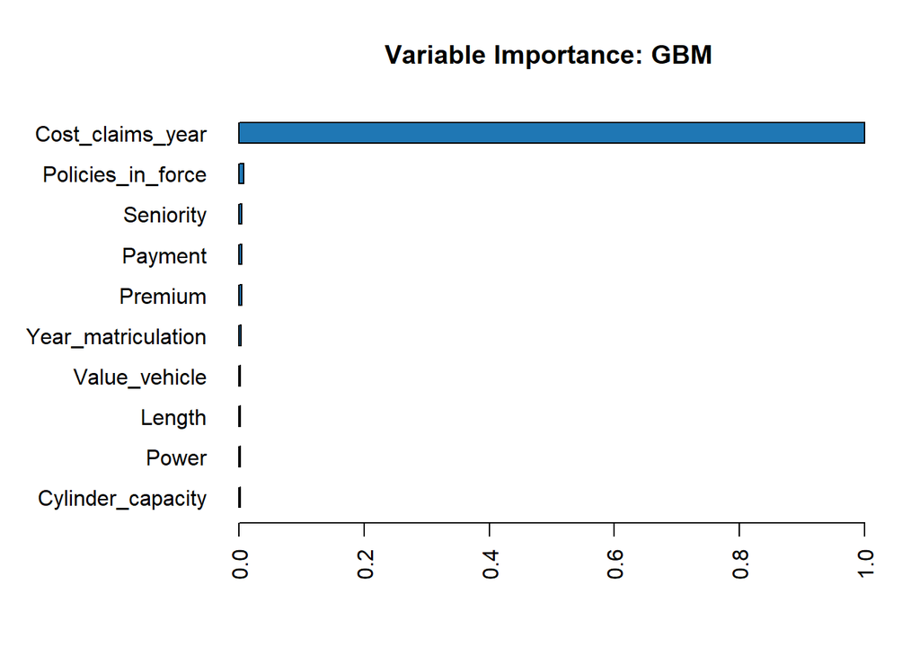

```r
h2o.varimp_plot(best_MOD)
```

## Etape 2 : Construction du véhiculier

Dans cette partie, nous aurons recours à l’un des algorithmes de classification non supervisé qui est le kmeans pour regrouper les prédictions en classes de risques homogènes.

#### Méthode de coude pour le choix du nombre de clusters

```r
# Charger les librairies
library(cluster)
library(factoextra)
# Plage de valeurs pour le nombre de clusters
k_range = 2:15

# Sélection des colonnes non numériques et celles sans valeurs manquantes
non_num_col = names(df_filtered)[!sapply(df_filtered, is.numeric)]
non_num_col_mis = non_num_col[!apply(df_filtered[non_num_col], 2, function(x) any(is.na(x)))]

# Filtrer les colonnes numériques et omettre les NA
DF_num = na.omit(DF[, sapply(DF, is.numeric)])

# Appliquer K-means sur les colonnes numériques sans NA
kmeans_models = lapply(k_range, function(k) {
  kmeans(DF_num, centers = k, nstart = 25)  # Utiliser nstart pour des résultats plus stables
})
```

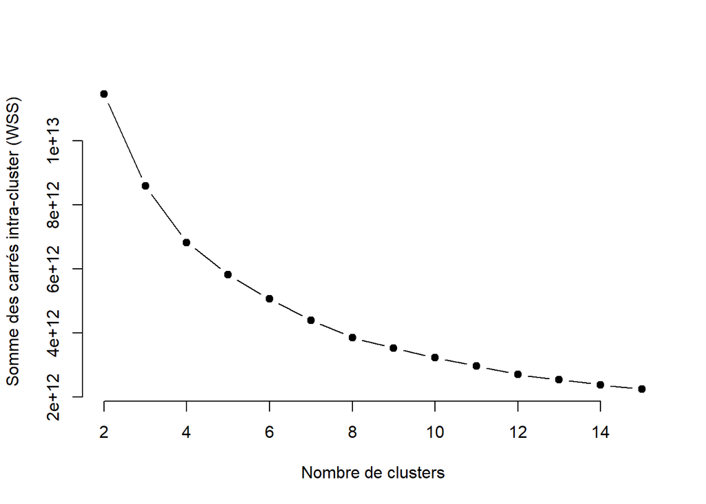

```r
# Calculer la somme des carrés intra-cluster pour chaque modèle
wss = sapply(kmeans_models, function(model) sum(model$withinss))

# Tracer le graphique de la somme des carrés intra-cluster en fonction du nombre de clusters
plot(k_range, wss, type = 'b', pch = 19, frame = FALSE,
     xlab = 'Nombre de clusters', ylab = 'Somme des carrés intra-cluster (WSS)')
```

D’après la courbe Elbow (méthode de coude), le nombre optimal de clusters est k=7.

Nous appliquons alors l’algorithme de kmeans en fixant le nb de cluters à 7

#### Kmeans appliqué au modele

```r
df2=df
B=h2o.predict(best_MOD, df2)
```

```
##   |                                                                              |                                                                      |   0%  |                                                                              |=========================================================…
```

```r
pred=as.vector(as.numeric(B))
DF$EFFET_V=pred
```

```r
scaled_pred=scale(DF$EFFET_V)
k_res=kmeans(scaled_pred, centers=7)
VEHICULIER=k_res$cluster
DF$VEHICULIER=VEHICULIER
```

#### Visualisation des Résultats de Classification Kmeans pour le 2eme modèle

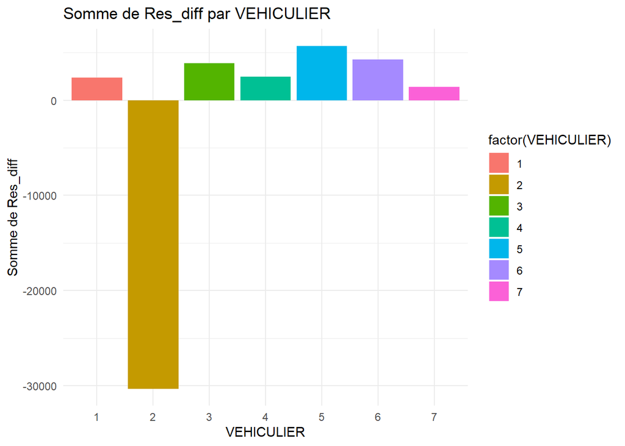

```r
library(ggplot2)


sum_freq_res <- aggregate(DF$Res_diff, by = list(VEHICULIER), sum)

# Renommer les colonnes pour plus de clarté
colnames(sum_freq_res) <- c("VEHICULIER", "Total_freq_res")

# Tracer l'histogramme
ggplot(sum_freq_res, aes(x = factor(VEHICULIER), y = Total_freq_res, fill = factor(VEHICULIER))) +
  geom_bar(stat = "identity") +
  labs(title = "Somme de Res_diff par VEHICULIER",
       x = "VEHICULIER",
       y = "Somme de Res_diff") +
  theme_minimal()
```